# ANALISIS DEL TURISMO EN ESPAÑA

Eduardo Yraola

#### **Introducción:**

La creciente subida del turismo en España es motivo de inteŕes económico en diversos sectores privados. En este sentido la hostelería es quizás uno de los más beneficiados sobre todo en los meses de verano. Por ello, la principal motivación de este trabajo es desarrollar un análisis específico de la tendencia turística en este sector.

Para ello se han usado datos de movimientos turísticos en fronteras proporcionados por Frontur y el INE. (Nota: Los datos contiene un histórico desde 2013 a 2015)

Frontur: http://estadisticas.tourspain.es/es-es/estadisticas/frontur/microdatos/paginas/default.aspx

INE: http://www.ine.es/prodyser/micro_frontur.htm

Los campos de interés contenidos en los datos han sido: el número de viajeros, la fecha, la nacionalidad, el destino (comunidad autónoma y provincia), los motivos de viaje, el tipo de alojamiento, y si se ha contratado paquete turístico.

En primer lugar, queremos ver cuales son las nacionalidades que potencialmente representan un target comercial para el sector hotelero Español, para a continuación determinar donde y cuando será un buen momento para aplicar una campaña de marketing orientada a estas.

#### **Top 5 de nacionalidades con mayor volumen de turistas en España**

Como punto de partida a continuación se presenta el ranking de las cinco primeras nacionalidades, alojadas en hotel, que más visitaron nuestro pais en 2015.

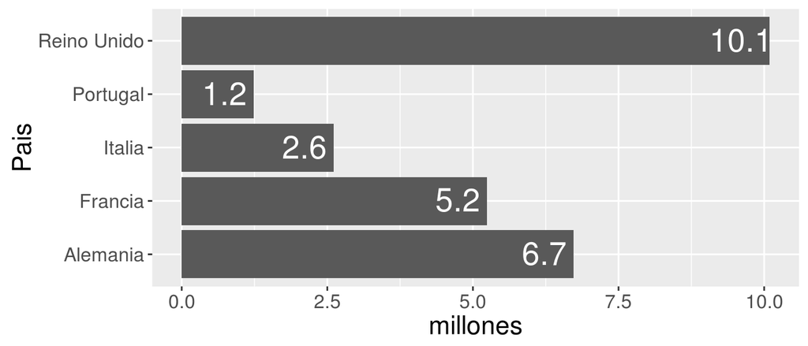

Viendo la tabla vemos que las nacionalidades que encabezan la lista son Reino Unido y Alemania.

#### **Correlación entre alojados en hotel y que han contratado paquete turístico**

A continuación queremos ver la cantidad de turistas alojados en hotel, con y sin contratación de paquete turístico, por nacionalidad.

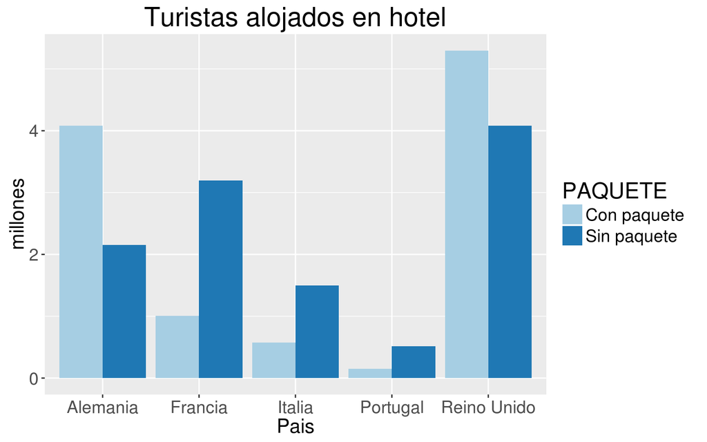

Se observa claramente que los Ingleses y los Alemanes, además de ser los que mas visitaron España en 2015, son mas propensos a contratar paquete de viajes. Por tanto estas dos nacionalidades represetarán el “target” comercial de este trabajo.

Ya que los meses de verano son de mayor interés de cara al turismo nuestra siguiente cuestión es asegurarnos de que la tendencia observada en el anterior gráfico también se da en esta época. Por tanto si filtramos solo para el mes de Agosto tenemos:

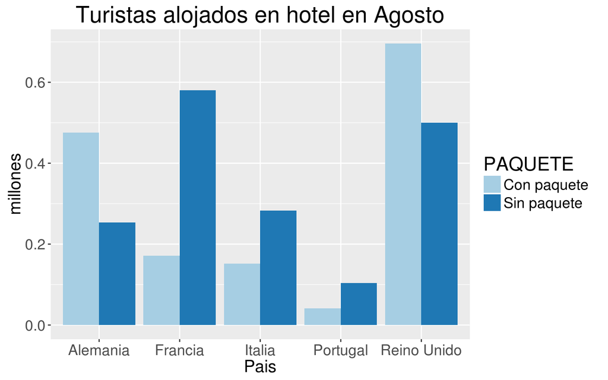

Comparando las dos gráficas anteriores vemos que tienen la misma forma, pero con distinta escala en el total de viajeros. Lo cual tiene sentido ya que nos quedamos con muchos menos viajeros al filtrar por un mes en concreto.

Una vez determinadas las dos nacionalidades de interés visualizamos el histórico mensual de la cantidad de turistas alojados en hotel, con y sin contratación de paquete turístico.

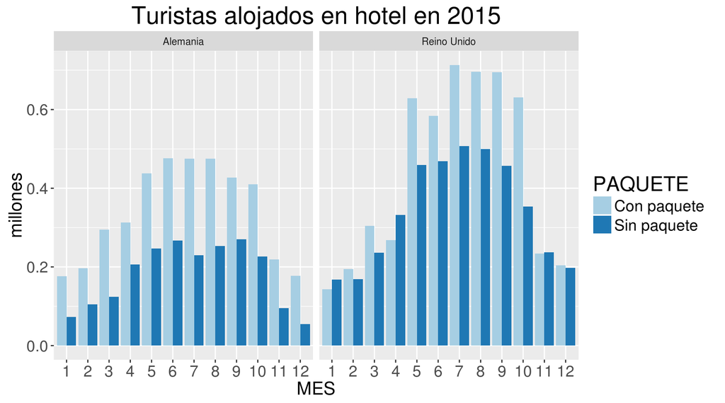

Como era de esperar las distribuciones crecen en los meses de verano y bajan en los meses de invierno. Aún así ambas nacionalidades son propensas a la contratación del paquete de viajes para practicamente todos los meses el año.

#### **Corrección a la muestra donada**

Antes de pasar a ver la distribución geográfica por provincias debemos hacer una corrección en los datos del número de viajeros. Esto se debe a que cuando la muestra recogida es baja, se completa con muestra donada de periodos anteriores al mes de referencia.  
En nuestros datos, la muestra donada son los viajeros con el campo Provincias igual a 00, y el campo CC_AA (Comunidad Autónoma) distinto de 00.

Vemos que volumen de muestra donada hay para el caso de viajeros Ingleses alojados en hotel para un mes concreto (Agosto).

```
## El volumen de muestra sin donación es 23045
```

```
## El volumen de muestra donada es 2391
```

Ahora queremos ver la cantidad de muestra donada por Provincia. Para ello vemos cuantos viajeros por Comunidad Autónoma hay con Provincia ==“00”.

```
##               Provincia Donación
## 2             Andalucía      146
## 4                Aragón        0
## 6              Asturias        0
## 8              Baleares        0
## 10             Canarias        0
## 12            Cantabria      612
## 14   Castilla La Mancha        0
## 16      Castilla y León        0
## 18             Cataluña      134
## 20 Comunidad Valenciana        6
## 22          Extremadura        0
## 24              Galicia     1483
## 26             La Rioja        0
## 28               Madrid        8
## 30               Murcia        0
## 32              Navarra        0
## 34           País Vasco        2
```

Por tanto, la cantidad total de muestra donada a toda una Comunidad Autónoma tiene que repartirse proporcionalmente entre todas las provincias de esa Comunidad Autónoma.

A continuación se muestra la función usada para aplicar el factor corrector por Provincia:

```r
# Creamos una función que genera la lista de factores de cada CC_AA
# que posteriormente tendremos que multiplicar por cada Provincia.

foo <- function(tmp){
  u=0
  for (i in 1:18){
    a<-sum(as.numeric(tmp[tmp$CC_AA==i,][tmp[tmp$CC_AA==i,]$Provincia==0,]$VIAJEROS)) #Suma de viajeros con Provincia=00 (muestra donada)
    b<-sum(as.numeric(tmp[tmp$CC_AA==i,][tmp[tmp$CC_AA==i,]$Provincia!=0,]$VIAJEROS)) #Suma de viajeros con Provincia!=00 (muestra recogida)
    u[i]=((a/b)+1); #Vector de factores
  }
  return(u)
}

df <- data.frame(foo(tmp)) #Tabla de factores
df<-cbind(1:18,df) # Añadimos una columna que corresponde a los valores de las CC_AA.
colnames(df)[colnames(df)=="1:18"] <- "CC_AA"
colnames(df)[colnames(df)=="foo.tmp."] <- "Factor"

tmp<-merge(tmp,df, by = "CC_AA") #Unimos las dos tablas por la CC_AA
tmp$VIAJEROS<-tmp$VIAJEROS*tmp$Factor #Multiplicamos el nº de Viajeros por el factor de correción obtenido.
tmp$Factor<- NULL #Ya no necesitamos la columna Factor

#Creamos una tabla que nos de el nº total de viajeros por Provincia en Agosto (ya que antes nos quedamos solo con este mes).
tmp<-dcast(tmp, Provincia ~ MES , value.var = "VIAJEROS", fun.aggregate = sum)
tmp$Provincia<-as.numeric(tmp$Provincia)
```

Una vez hecha la corrección podemos visualizar correctamente la cantidad de turistas Ingleses alojados en hotel por Provincia. El valor numérico que aparece dentro de cada Provincia representa el porcentaje de esta cantidad.

#### **Distribución de turistas Ingleses en Agosto**

[figure not shown]

[figure not shown]

El dato mas llamativo es que el 38% de los Ingleses van a Baleares en Agosto, seguido de Canarias (11.46%) y Barcelona (8,76%).

#### **Distribución de turistas Alemanes en Agosto**

A continuación realizamos la misma corrección para los turistas Alemanes alojados en hotel en Agosto y visualizamos:

[figure not shown]

[figure not shown]

Gracias a esta información sabemos que localizaciones (Provincias) deberíamos elegir para desarrollar un paquete de viajes orientado a estas nacionalidades.

#### **Predicción del turismo**

Como punto último de este estudio queremos predecir la evolución del número de visitas de estas dos nacionalidades. Para ello se ha usado un modelo de serie temporal.

Para los Ingleses con paquete de viajes.

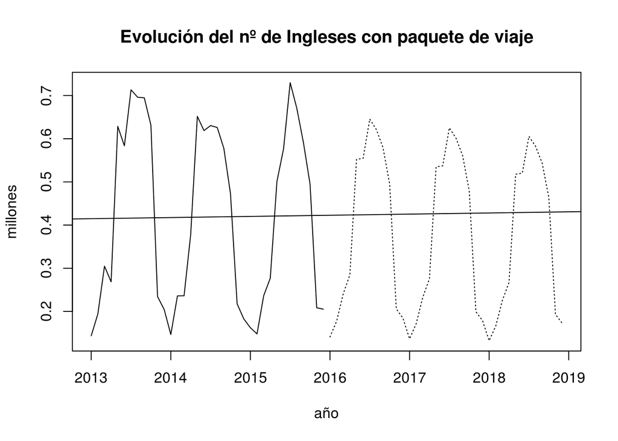

La predicción tiende a la estabilidad aunque el número de viajeros anual parece que se reduce.

Para los Ingleses sin paquete de viajes.

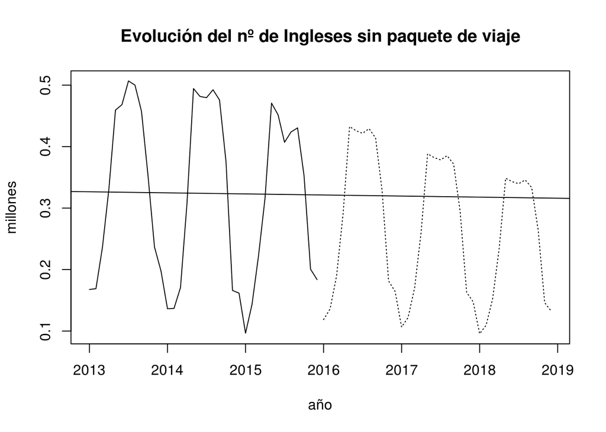

La predicción tiende a disminuir conforme avanzan los años.

Para los Alemanes con paquete de viajes.

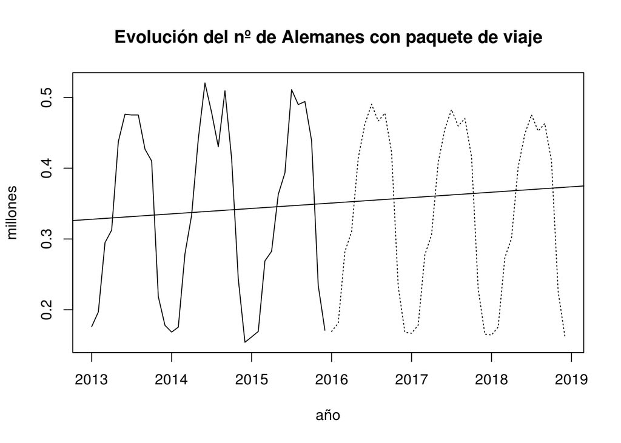

La predicción y el número de viajeros anual parece que se mantiene constante.

Para los Alemanes sin paquete de viajes.

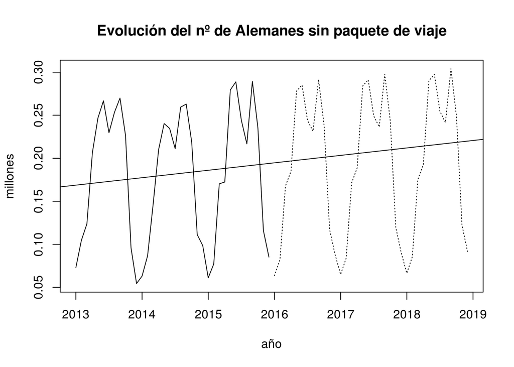

La predicción tiende a aumentar conforme avanzan los años.

Con estos resultados vemos que es mas crítico fomentar del turismo Ingles con el fin de aumentar el número de visitas de este pais.

#### **Conclusiones**

Viendo todos los resultados y con el objetivo de aumentar el número de visitas turisticas de un cliente hotelero podemos concluir que interesaría desarrollar, por parte de los responsables de marketing, paquetes de viajes principalmente orientados a Ingleses; y enfocarlo sobre todo hacia clientes que quieran visitar las Islas Baleares.

No obstante aplicándolo este modelo hacia un cliente Alemán que se quiera hospedar en el mismo destino también debería generar beneficios.